# visStatistics: The right test, visualised

The R package `visStatistics` allows for rapid visualisation and statistical analysis of raw data. It automatically selects and visualises the most appropriate statistical hypothesis test between a response (`varsample`) and a feature (`varfactor`) within a `data.frame`. The package focuses on visualising the selected test using appropriate plots - such as box plots, bar charts, regression lines with confidence bands, mosaic plots, residual plots and Q–Q plots. Each plot is annotated with relevant test statistics and, where applicable, assumption checks and post-hoc results. The scripted workflow is particularly well suited for interactive interfaces, where users access data only through a graphical front end backed by server-side R sessions, as well as for quick data exploration, for example, in statistical consulting contexts.

# Getting Started

A minimal function call looks of its main function `visstat()` looks like:

```r
visstat(dataframe, varsample = "response", varfactor = "feature")
```

The input must be a column - based `data.frame`, and `varsample` and `varfactor` are character strings naming columns of that data frame.

The function selects a statistical test based on the class of the response and feature variables, the number of levels in categorical variables, and conditions such as normality and homoscedasticity.

The automatically generated output figures illustrate the selected statistical test, display the main test statistics, and include assumption checks and post hoc comparisons when applicable. The primary test results are returned as a list object.

# Installation of latest stable version from CRAN

**1.** Install the package

```r
install.packages("visStatistics")
```

**2.** Load the package

```r
library(visStatistics)
```

# Installation of the development version from GitHub

**1.** Install **devtools** from CRAN if not already installed:

```r
install.packages("devtools")
```

**2.** Load the **devtools** package:

```r
library(devtools)
```

**3.** Install the `visStatistics` package from GitHub:

```r
install_github("shhschilling/visStatistics")
```

**4.** Load the `visStatistics` package:

```r
library(visStatistics)
```

**5.** View help for the main function:

```r
? visstat
```

**6.** Study all the details of the package in its vignette:

```r
vignette("visStatistics")
```

# Decision logic

Throughout the remainder, data of class `"numeric"` or `"integer"` are referred as numerical, while data of class `"factor"` are referred to as categorical. The choice of statistical tests performed by the function `visstat()` depends on whether the data are numerical or categorical, the number of levels in the categorical variable, and the distribution of the data. The function prioritizes interpretable visual output and tests that remain valid under the the following decision logic:

**(1)** When the response is numerical and the predictor is categorical, tests of central tendency are performed. If the predictor has two levels, `t.test()` is used if both groups have more than 30 observations (Lumley et al. (2002) <doi:10.1146/annurev.publhealth.23.100901.140546>;). For smaller samples, normality is assessed using `shapiro.test()`. If both groups return p-values greater than `alpha`, `t.test()` is applied; otherwise, `wilcox.test()` is used. For predictors with more than two levels, `aov()` is initially fitted. Residual normality is tested with `shapiro.test()` and `ad.test()`. If `p > alpha` for either test, normality is assumed. Homogeneity of variance is tested with `bartlett.test()`. If `p > alpha`, `aov()` with `TukeyHSD()` is used. If `p <= alpha`, `oneway.test()` is applied with `TukeyHSD()`. If residuals are not normal, `kruskal.test()` with `pairwise.wilcox.test()` is used.

[figure not shown]

Figure: Decision logic used by `visstat()`. Test selection depends on data type and assumptions.

**(2)** When both the response and predictor are numerical, a linear model `lm()` is fitted, with residual diagnostics and a confidence band plot.

**(3)** When both variables are categorical, `visstat()` uses `chisq.test()` or `fisher.test()` depending on expected counts, following Cochran’s rule (Cochran (1954) <doi:10.2307/3001666>;).

Note: Except for the user - adjustable `conf.level` parameter, all statistical tests are applied using their default settings from the corresponding base R functions (e.g., `t.test()`). As a consequence, paired tests are not currently supported. Furthermore, since the main purpose of this package is to visualize statistical test results, only simple linear regression is implemented. For a more detailed description of the underlying decision logic see

```r
vignette("visStatistics")
```

# Examples

```r
library(visStatistics)
```

In this section, function names in parentheses in the headings indicate the statistical test selected by the decision logic of `visstat()`.

## Numerical response and categorical feature

When the response is numerical and the feature is categorical, test of central tendencies are selected.

### Welch’s t-test (`t.test()`)

#### InsectSprays dataset

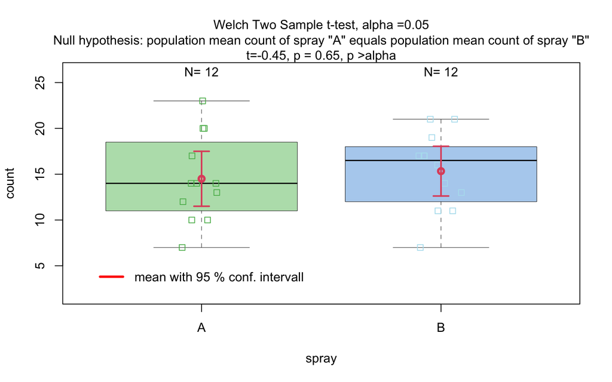

```r
insect_sprays_a_b <-
InsectSprays[which(InsectSprays$spray == "A" |
InsectSprays$spray == "B"), ]
insect_sprays_a_b$spray <- factor(insect_sprays_a_b$spray)
visstat(insect_sprays_a_b, "count", "spray")
```

#### mtcars dataset

```r
mtcars$am <- as.factor(mtcars$am)
t_test_statistics <- visstat(mtcars, "mpg", "am")
```

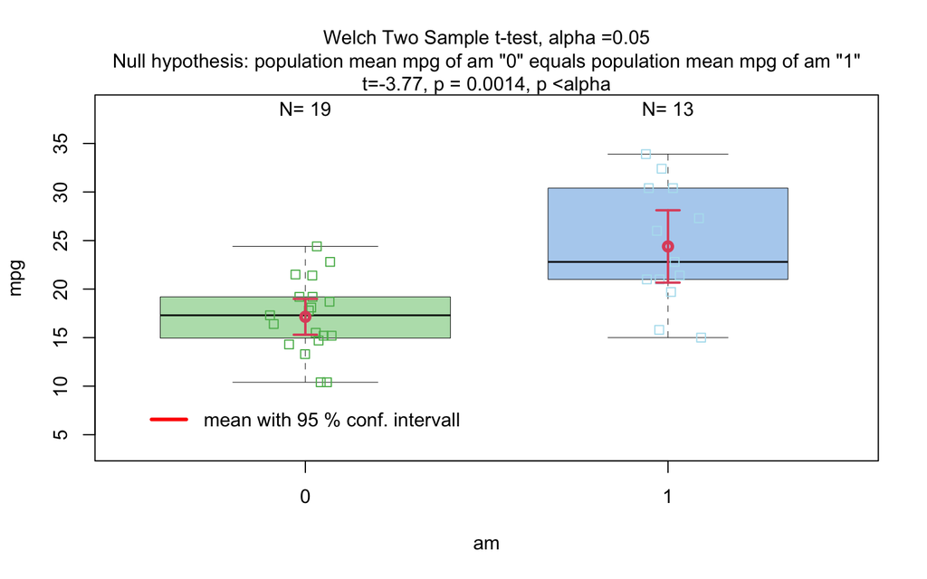

```r
#t_test_statistics
```

### Wilcoxon rank-sum test (`wilcox.test()`)

```r
grades_gender <- data.frame(
  sex = factor(rep(c("girl", "boy"), times = c(21, 23))),
  grade = c(
    19.3, 18.1, 15.2, 18.3, 7.9, 6.2, 19.4, 20.3, 9.3, 11.3,
    18.2, 17.5, 10.2, 20.1, 13.3, 17.2, 15.1, 16.2, 17.0, 16.5, 5.1,
    15.3, 17.1, 14.8, 15.4, 14.4, 7.5, 15.5, 6.0, 17.4, 7.3, 14.3,
    13.5, 8.0, 19.5, 13.4, 17.9, 17.7, 16.4, 15.6, 17.3, 19.9, 4.4, 2.1
  )
)

wilcoxon_statistics <- visstat(grades_gender, "grade", "sex")
```

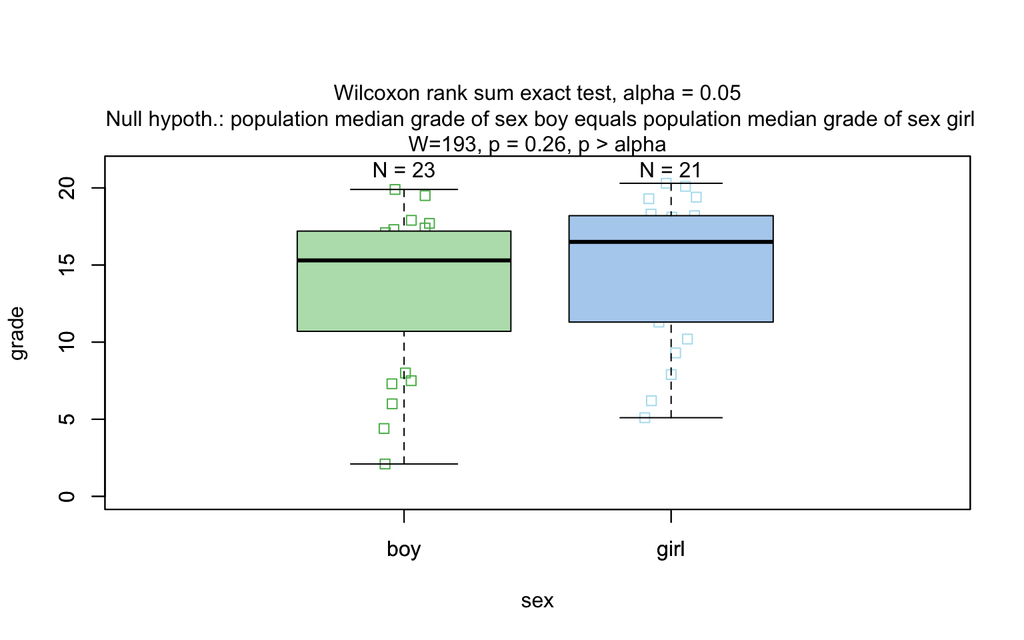

### Fisher’s one-way ANOVA (`aov()`)

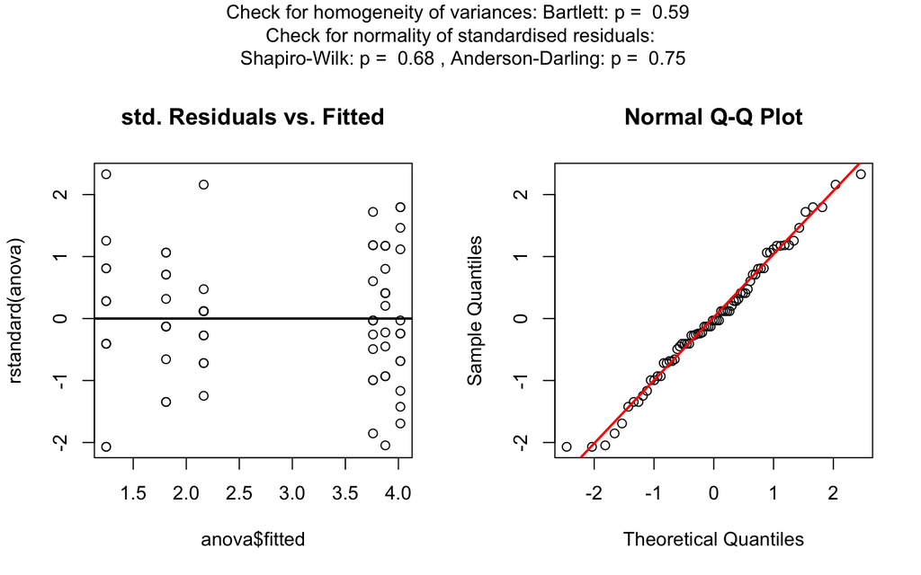

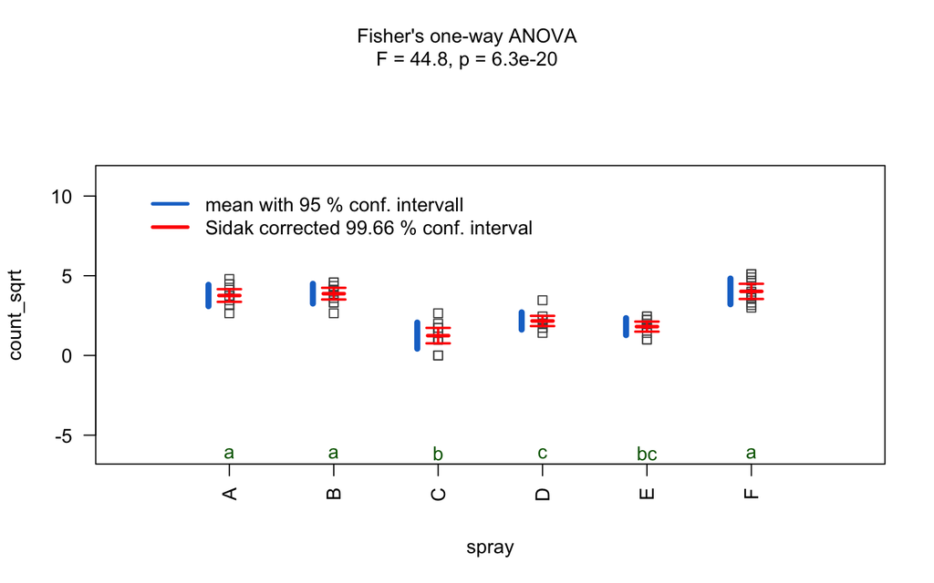

```r
insect_sprays_tr <- InsectSprays
insect_sprays_tr$count_sqrt <- sqrt(InsectSprays$count)
visstat(insect_sprays_tr, "count_sqrt", "spray")
```

### Welch’s heteroscedastic one-way ANOVA (`oneway.test()`)

```r
one_way_npk <- visstat(npk, "yield", "block")
```

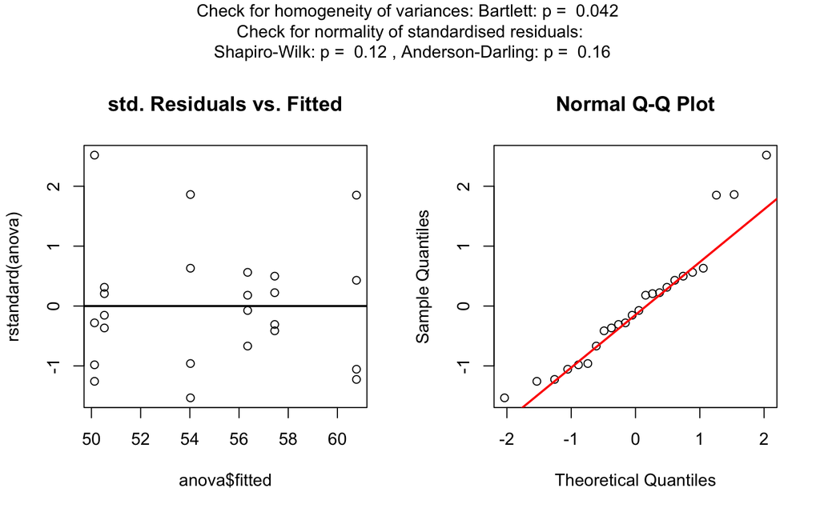

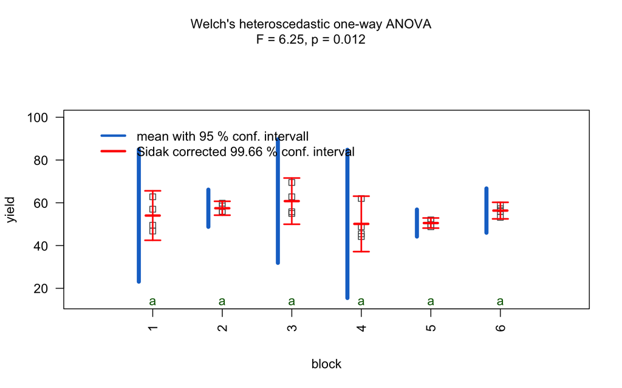

### Kruskal–Wallis test (`kruskal.test()`)

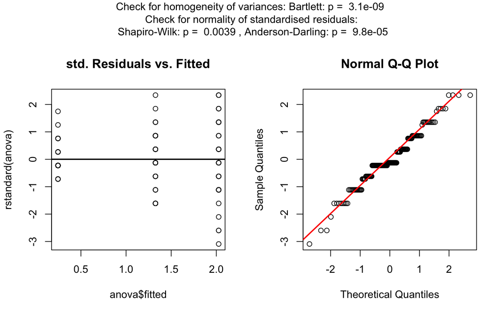

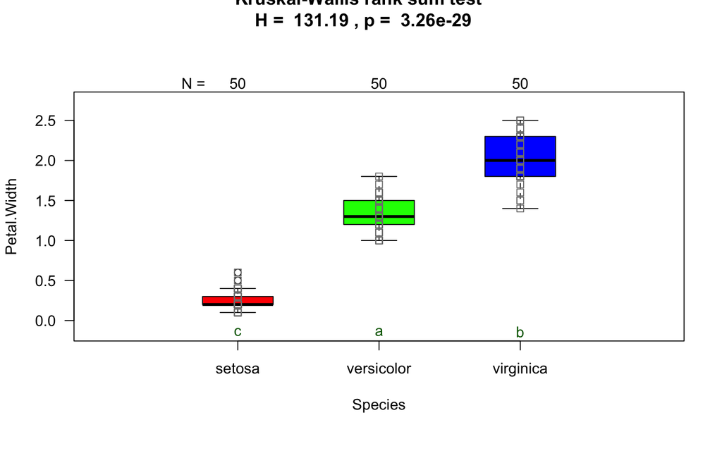

```r
visstat(iris, "Petal.Width", "Species")
```

The generated graphs can be saved in all available formats of the `Cairo` package. Here we save the graphical output of type “pdf” in the `plotDirectory` `tempdir()`:

```r
visstat(
iris,
"Petal.Width",
"Species",
graphicsoutput = "pdf",
plotDirectory = tempdir()
)
```

## Numerical response and numerical feature:

### Simple linear Regression (`lm()`)

```r
linreg_cars <- visstat(cars, "dist", "speed")
```

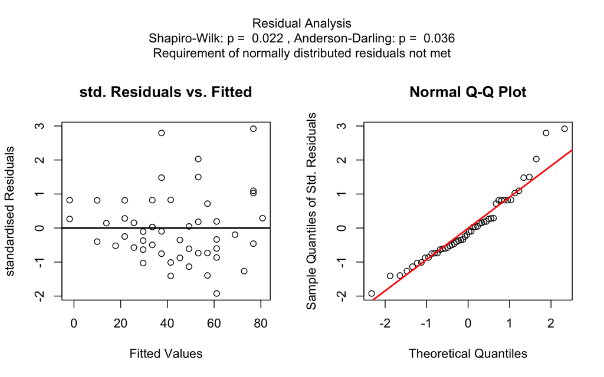

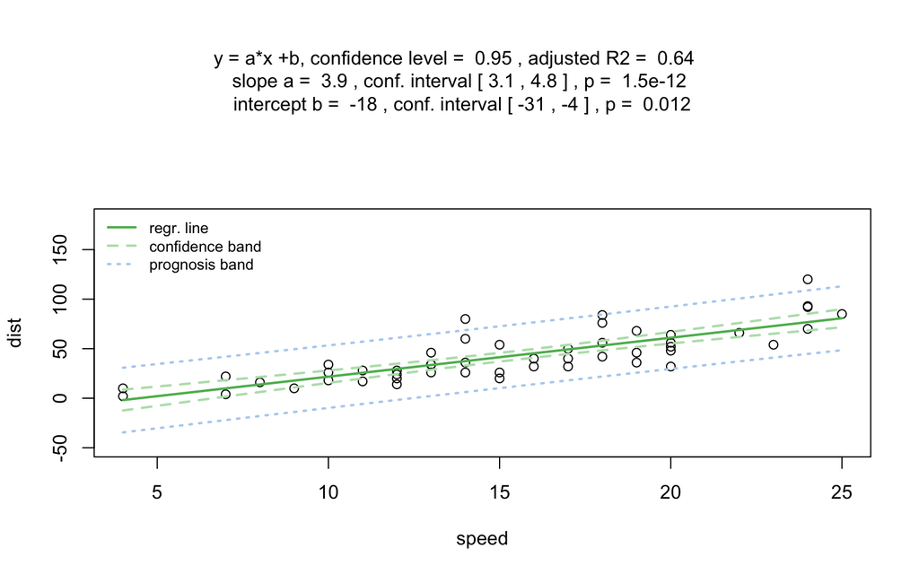

Increasing the confidence level `conf.level` from the default 0.95 to 0.99 leads two wider confidence and prediction bands:

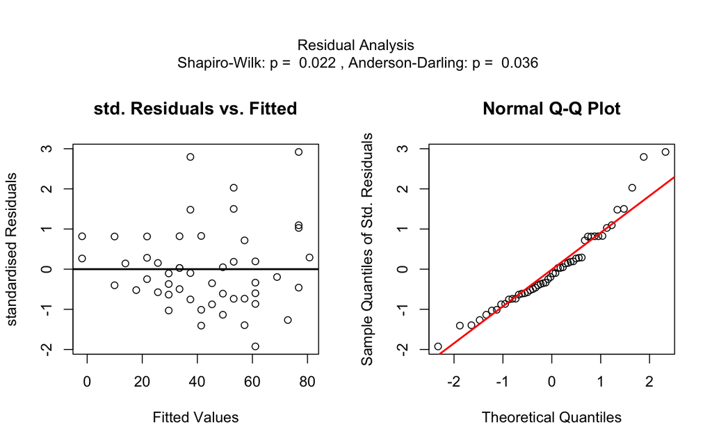

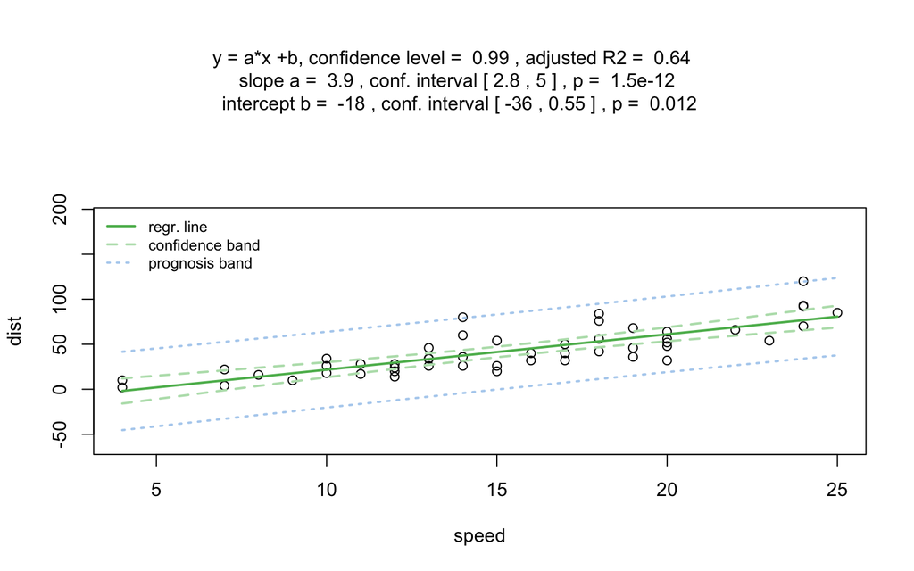

## Categorical response and categorical feature

### Pearson’s $\chi^2$-test (`chisq.test()`)

Count datasets are often presented as multidimensional arrays, so - called contingency tables, whereas `visstat()` requires a `data.frame` with a column structure. Arrays can be transformed to this column wise structure with the helper function `counts_to_cases()`:

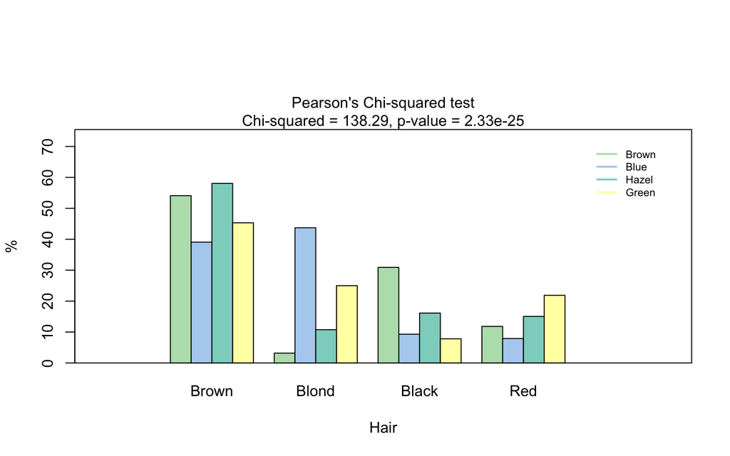

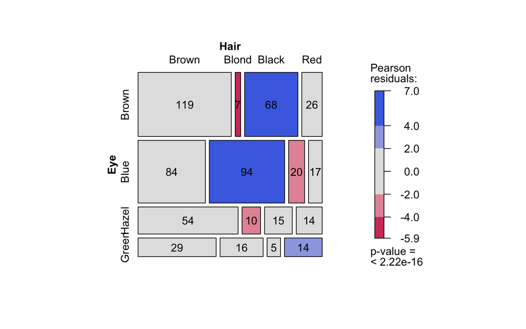

```r
hair_eye_color_df <- counts_to_cases(as.data.frame(HairEyeColor))
visstat(hair_eye_color_df, "Hair", "Eye")
```

### Fisher’s exact test (`fisher.test()`)

```r
hair_eye_color_male <- HairEyeColor[, , 1]
# Slice out a 2 by 2 contingency table
black_brown_hazel_green_male <- hair_eye_color_male[1:2, 3:4]
# Transform to data frame
black_brown_hazel_green_male <- counts_to_cases(as.data.frame(black_brown_hazel_green_male))
# Fisher test
fisher_stats <- visstat(black_brown_hazel_green_male, "Hair", "Eye")
```

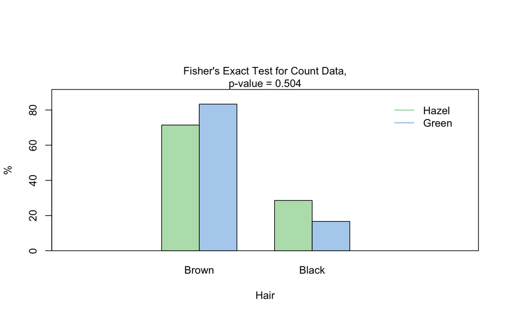

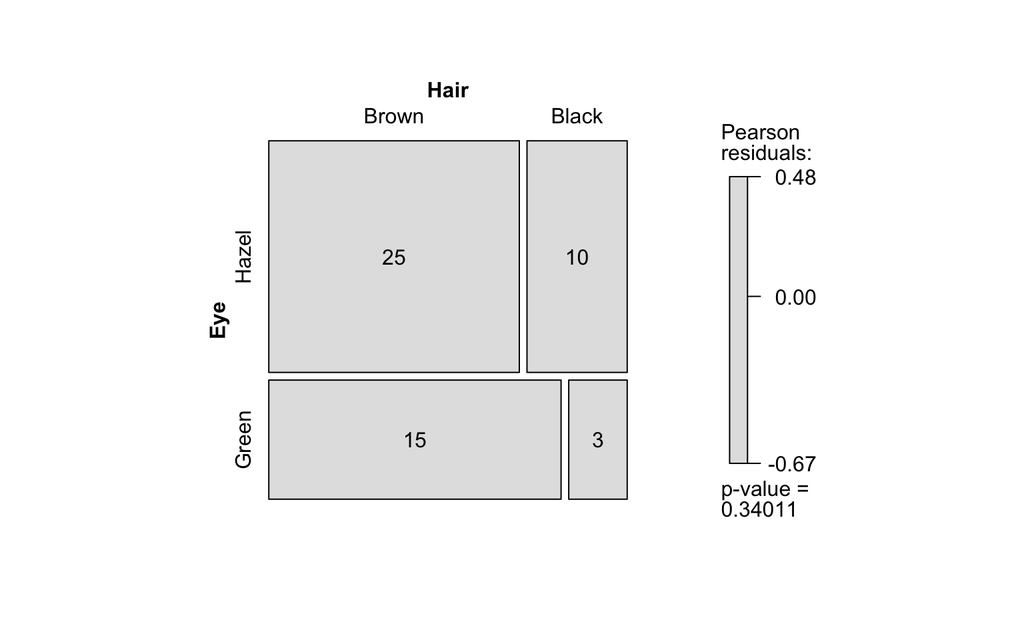

## Implemented tests

Note that all test are implemented with their default settings, with the exception of the user-adjustable `conf.level`.

### Numerical response and categorical feature

#### Main tests

`t.test()`, `wilcox.test()`, `aov()`, `oneway.test()`, `kruskal.test()`

#### Normality assumption check

`shapiro.test()` and `ad.test()`

#### Homoscedasticity assumption check

`bartlett.test()`

#### Post-hoc tests

- `TukeyHSD()` (used following `aov()`and `oneway.test()`)
- `pairwise.wilcox.test()` (used following `kruskal.test()`)

### Numerical response and numerical feature:

Simple linear regression: `lm()`

Note that multiple linear regression models are not implemented, as the package focuses on the visualisation of data, not model building.

### Categorical response and categorical feature

- `chisq.test()` (default for larger samples)
- `fisher.test()` (used for small expected cell counts based on Cochran’s rule (Cochran 1954))

## References

Cochran, William G. 1954. “The Combination of Estimates from Different Experiments.” *Biometrics* 10 (1): 101. https://doi.org/10.2307/3001666.